# Prosper Loan Data Exploration

## by Puneet Sharma

## Investigation Overview

> What factors affect a loan’s outcome status?  
> What affects the borrower’s APR or interest rate?  
> Are there differences between loans depending on how large the original loan amount was?

## Dataset Overview

> This data set contains 113,937 loans with 81 variables on each loan, including loan amount, borrower rate (or interest rate), current loan status, borrower income, and many others.

## Interest Rate vs Credit Score with Loan Status

> Lender: Give loan to people with high Credit Score.  
> Borrower: Keep up your Credit Score to get good Interest Rate and higher loan amount.

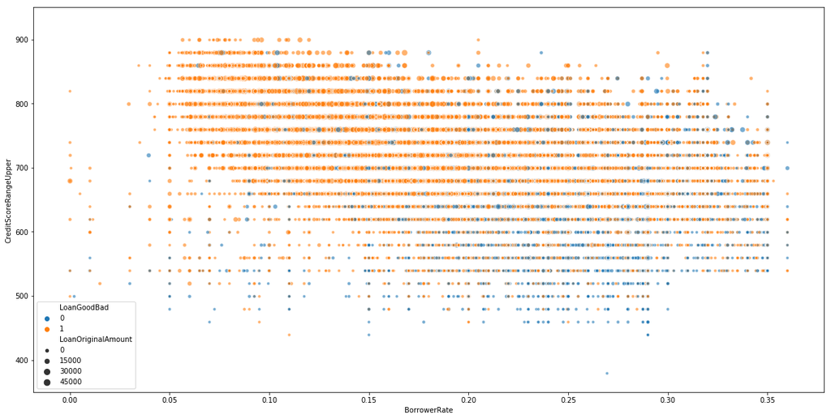

```python
plt.figure(figsize=[20, 10])
sb.scatterplot(x="BorrowerRate", y="CreditScoreRangeUpper", hue='LoanGoodBad', size='LoanOriginalAmount', alpha=0.6, data=df)
plt.ylim(350, 950);
```

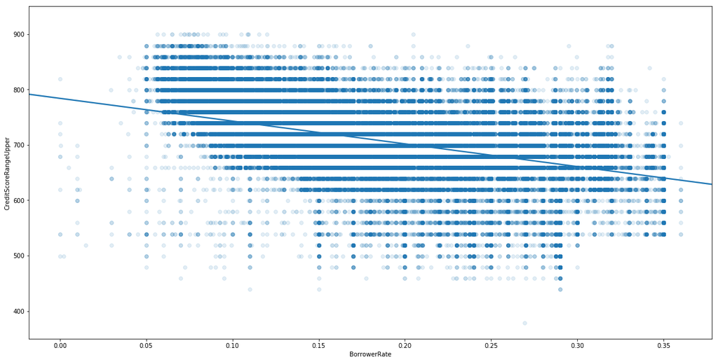

```python
plt.figure(figsize=[20, 10])
sb.regplot(x="BorrowerRate", y="CreditScoreRangeUpper", scatter_kws={'alpha': 1/8}, data=df)
plt.ylim(350, 950);
```

## Interest Rate vs Bank Card Utilization with Loan Status and Loan Amount

> Lender: People getting good Interest Rate are likely end up having good status.  
> Borrower: High Bank Card Utilization will likely cause high Interest Rate and smaller Loan Amount.

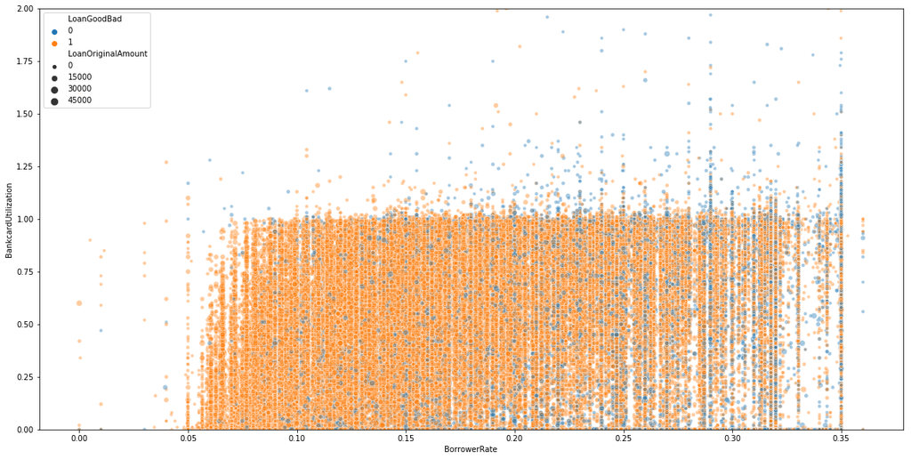

```python
plt.figure(figsize=[20, 10])
sb.scatterplot(x="BorrowerRate", y="BankcardUtilization", hue='LoanGoodBad', size='LoanOriginalAmount', alpha=0.4, data=df)
plt.ylim(0, 2);
```

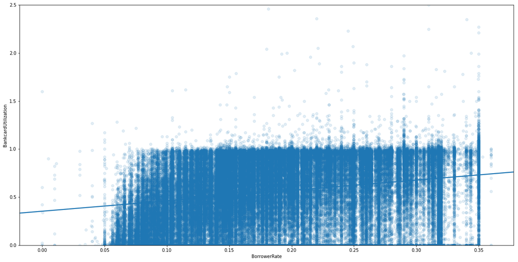

```python
plt.figure(figsize=[20, 10])
sb.regplot(x="BorrowerRate", y="BankcardUtilization", scatter_kws={'alpha': 1/8}, data=df)
plt.ylim(0, 2.5);
```

## Credit Score vs Bank Card Utilization with Loan Status and Loan Amount

> Borrower: Keep your Bank Card Utilization low to get high Credit Score.  
> Borrower: Hight Credit Score will get you higher Loam Amount.

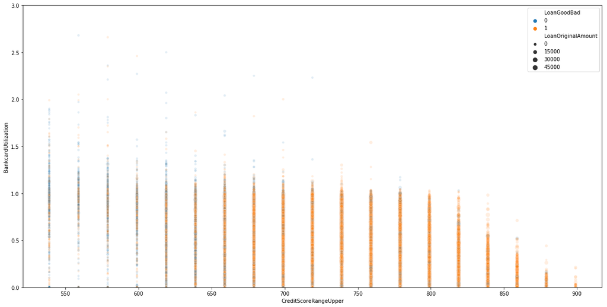

```python
plt.figure(figsize=[20, 10])
sb.scatterplot(x="CreditScoreRangeUpper", y='BankcardUtilization', hue='LoanGoodBad', size='LoanOriginalAmount', alpha=1/8, data=df);
plt.ylim(0, 3);
```

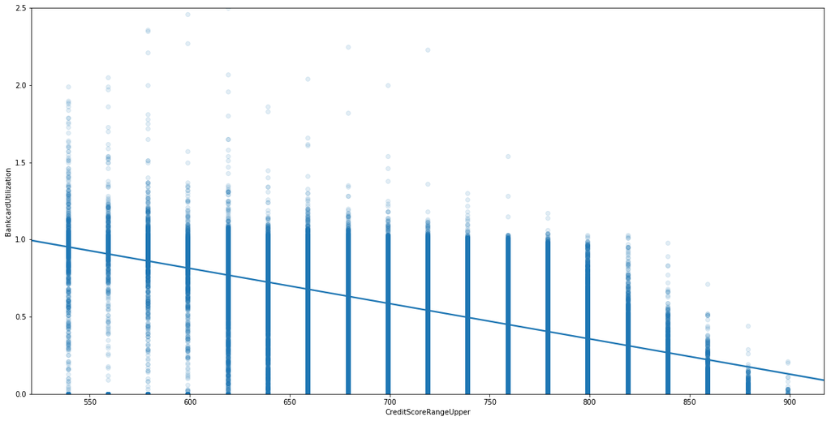

```python
plt.figure(figsize=[20, 10])
sb.regplot(x='CreditScoreRangeUpper', y='BankcardUtilization', scatter_kws={'alpha': 1/8}, data=df)
plt.ylim(0, 2.5);
```